# BTC_ETH_USD_TRIANGLE_ARB_STRATEGY_Analysis_1

```python
import pandas as pd
import numpy as np
from datetime import timedelta
import datetime
import matplotlib.pyplot as plt
from time import time
from pprint import pprint # to pretty print the cursor result.
import pymongo
import dask.dataframe as dd
import matplotlib.pyplot as plt; plt.rcdefaults()


### Import tensorflow and set log settings
import tensorflow as tf
tf.logging.set_verbosity(tf.logging.FATAL) # FATAL, WARN, INFO, DEBUG

#Hide Warnings
import warnings
warnings.filterwarnings('ignore')

# For adding bar to toggle code
from IPython.display import display
from IPython.display import HTML
import IPython.core.display as di # Example: di.display_html('<h3>%s:</h3>' % str, raw=True)

# This line will hide code by default when the notebook is exported as HTML
di.display_html('<script>jQuery(function() {if (jQuery("body.notebook_app").length == 0) { jQuery(".input_area").toggle(); jQuery(".prompt").toggle();}});</script>', raw=True)

# This line will add a button to toggle visibility of code blocks, for use with the HTML export version
di.display_html('''<button onclick="jQuery('.input_area').toggle(); jQuery('.prompt').toggle();">Toggle Code Visibility in Notebook</button>''', raw=True)
```

```python
data = pd.read_csv('TRIANGLE_ARB.csv')
del data['Unnamed: 0']
data.head(3)
```

|  | polo_time_0 | polo_time_1 | BTCETH_PRICE | gdax_time_ETHUSD | ETHUSD_PRICE | gdax_time_BTCUSD | BTCUSD_PRICE |
| --- | --- | --- | --- | --- | --- | --- | --- |
| 0 | 2017-07-11 02:04:43.239583 | 2017-07-11 02:04:43.643355 | 0.078497 | 2017-07-11T07:04:45.138000Z | 182.83 | 2017-07-11T07:04:29.281000Z | 2302.56 |
| 1 | 2017-07-11 02:04:49.221453 | 2017-07-11 02:04:49.326083 | 0.078631 | 2017-07-11T07:04:49.375000Z | 182.80 | 2017-07-11T07:04:46.809000Z | 2302.56 |
| 2 | 2017-07-11 02:04:54.605551 | 2017-07-11 02:04:54.720606 | 0.078497 | 2017-07-11T07:04:55.862000Z | 181.60 | 2017-07-11T07:04:46.809000Z | 2302.56 |

##### First need to analyze differences in time stamps

```python
print ('First Row of Data:')
print (data.iloc[0])
```

```
First Row of Data:
polo_time_0          2017-07-11 02:04:43.239583
polo_time_1          2017-07-11 02:04:43.643355
BTCETH_PRICE                          0.0784967
gdax_time_ETHUSD    2017-07-11T07:04:45.138000Z
ETHUSD_PRICE                             182.83
gdax_time_BTCUSD    2017-07-11T07:04:29.281000Z
BTCUSD_PRICE                            2302.56
Name: 0, dtype: object
```

##### In future adjust system to record data in UTC so local machine data records apples to apples with GDAX api data (and other exchanges that will be added. For now, just converting the GDAX timestamps to central time.

```python
from datetime import timedelta

data['polo_time_0'] = pd.DatetimeIndex(data['polo_time_0']).tz_localize('US/Central') #.tz_convert('US/Central')
data['polo_time_1'] = pd.DatetimeIndex(data['polo_time_1']).tz_localize('US/Central') #.tz_convert('US/Central')

data['gdax_time_ETHUSD'] = pd.DatetimeIndex(data['gdax_time_ETHUSD']).tz_localize('UTC').tz_convert('US/Central')
data['gdax_time_BTCUSD'] = pd.DatetimeIndex(data['gdax_time_BTCUSD']).tz_localize('UTC').tz_convert('US/Central')
```

```python
data.head()
```

|  | polo_time_0 | polo_time_1 | BTCETH_PRICE | gdax_time_ETHUSD | ETHUSD_PRICE | gdax_time_BTCUSD | BTCUSD_PRICE |
| --- | --- | --- | --- | --- | --- | --- | --- |
| 0 | 2017-07-11 02:04:43.239583-05:00 | 2017-07-11 02:04:43.643355-05:00 | 0.078497 | 2017-07-11 02:04:45.138000-05:00 | 182.83 | 2017-07-11 02:04:29.281000-05:00 | 2302.56 |
| 1 | 2017-07-11 02:04:49.221453-05:00 | 2017-07-11 02:04:49.326083-05:00 | 0.078631 | 2017-07-11 02:04:49.375000-05:00 | 182.80 | 2017-07-11 02:04:46.809000-05:00 | 2302.56 |
| 2 | 2017-07-11 02:04:54.605551-05:00 | 2017-07-11 02:04:54.720606-05:00 | 0.078497 | 2017-07-11 02:04:55.862000-05:00 | 181.60 | 2017-07-11 02:04:46.809000-05:00 | 2302.56 |
| 3 | 2017-07-11 02:05:00.122692-05:00 | 2017-07-11 02:05:00.287866-05:00 | 0.078497 | 2017-07-11 02:04:58.567000-05:00 | 181.05 | 2017-07-11 02:04:59.356000-05:00 | 2304.26 |
| 4 | 2017-07-11 02:05:05.774416-05:00 | 2017-07-11 02:05:05.902462-05:00 | 0.078396 | 2017-07-11 02:05:07.877000-05:00 | 181.29 | 2017-07-11 02:05:06.276000-05:00 | 2302.96 |

```python
print (data.dtypes)
```

```
polo_time_0         datetime64[ns, US/Central]
polo_time_1         datetime64[ns, US/Central]
BTCETH_PRICE                           float64
gdax_time_ETHUSD    datetime64[ns, US/Central]
ETHUSD_PRICE                           float64
gdax_time_BTCUSD    datetime64[ns, US/Central]
BTCUSD_PRICE                           float64
dtype: object
```

#### Calculate Time Delta in seconds between the 3 pairs, and their various combinations

##### Let's use polo_time_1 for BTCETH

Note...the time stamp for Poloniex is not the trade time, but rather the time my system made the call to the API (before and after). I have still not located the way to get the timestamp of the market data in the API call

In future, it might make sense to manually watch the exchange while also making API calls to help determine how much latency we are dealing with. This will also help when the project shifts to executing trades.

All calculations will subtract the API call made first in the script from the API call made subsequently

```python
data['BTCUSD_ETHUSD_Delta'] = data['gdax_time_BTCUSD'] - data['gdax_time_ETHUSD']
data['BTCUSD_BTCETH_Delta'] = data['gdax_time_BTCUSD'] - data['polo_time_1']
data['ETHUSD_BTCETH_Delta'] = data['gdax_time_ETHUSD'] - data['polo_time_1']
data.head()
```

|  | polo_time_0 | polo_time_1 | BTCETH_PRICE | gdax_time_ETHUSD | ETHUSD_PRICE | gdax_time_BTCUSD | BTCUSD_PRICE | BTCUSD_ETHUSD_Delta | BTCUSD_BTCETH_Delta | ETHUSD_BTCETH_Delta |
| --- | --- | --- | --- | --- | --- | --- | --- | --- | --- | --- |
| 0 | 2017-07-11 02:04:43.239583-05:00 | 2017-07-11 02:04:43.643355-05:00 | 0.078497 | 2017-07-11 02:04:45.138000-05:00 | 182.83 | 2017-07-11 02:04:29.281000-05:00 | 2302.56 | -1 days +23:59:44.143000 | -1 days +23:59:45.637645 | 00:00:01.494645 |
| 1 | 2017-07-11 02:04:49.221453-05:00 | 2017-07-11 02:04:49.326083-05:00 | 0.078631 | 2017-07-11 02:04:49.375000-05:00 | 182.80 | 2017-07-11 02:04:46.809000-05:00 | 2302.56 | -1 days +23:59:57.434000 | -1 days +23:59:57.482917 | 00:00:00.048917 |
| 2 | 2017-07-11 02:04:54.605551-05:00 | 2017-07-11 02:04:54.720606-05:00 | 0.078497 | 2017-07-11 02:04:55.862000-05:00 | 181.60 | 2017-07-11 02:04:46.809000-05:00 | 2302.56 | -1 days +23:59:50.947000 | -1 days +23:59:52.088394 | 00:00:01.141394 |
| 3 | 2017-07-11 02:05:00.122692-05:00 | 2017-07-11 02:05:00.287866-05:00 | 0.078497 | 2017-07-11 02:04:58.567000-05:00 | 181.05 | 2017-07-11 02:04:59.356000-05:00 | 2304.26 | 00:00:00.789000 | -1 days +23:59:59.068134 | -1 days +23:59:58.279134 |
| 4 | 2017-07-11 02:05:05.774416-05:00 | 2017-07-11 02:05:05.902462-05:00 | 0.078396 | 2017-07-11 02:05:07.877000-05:00 | 181.29 | 2017-07-11 02:05:06.276000-05:00 | 2302.96 | -1 days +23:59:58.399000 | 00:00:00.373538 | 00:00:01.974538 |

```python
print (data.dtypes)
```

```
polo_time_0            datetime64[ns, US/Central]
polo_time_1            datetime64[ns, US/Central]
BTCETH_PRICE                              float64
gdax_time_ETHUSD       datetime64[ns, US/Central]
ETHUSD_PRICE                              float64
gdax_time_BTCUSD       datetime64[ns, US/Central]
BTCUSD_PRICE                              float64
BTCUSD_ETHUSD_Delta               timedelta64[ns]
BTCUSD_BTCETH_Delta               timedelta64[ns]
ETHUSD_BTCETH_Delta               timedelta64[ns]
dtype: object
```

##### Convert Time Delta to Seconds

```python
#data['seconds'] = data['time_delta'] / np.timedelta64(1,'s')

#### NOTE - Using .values enables this to work (was a frustrating little piece of tinkering)
data['BTCUSD_ETHUSD_Seconds'] = data['BTCUSD_ETHUSD_Delta'].values / np.timedelta64(1,'s')
data['BTCUSD_BTCETH_Seconds'] = data['BTCUSD_BTCETH_Delta'].values / np.timedelta64(1,'s')
data['ETHUSD_BTCETH_Seconds'] = data['ETHUSD_BTCETH_Delta'].values / np.timedelta64(1,'s')
data.head()
```

|  | polo_time_0 | polo_time_1 | BTCETH_PRICE | gdax_time_ETHUSD | ETHUSD_PRICE | gdax_time_BTCUSD | BTCUSD_PRICE | BTCUSD_ETHUSD_Delta | BTCUSD_BTCETH_Delta | ETHUSD_BTCETH_Delta | BTCUSD_ETHUSD_Seconds | BTCUSD_BTCETH_Seconds | ETHUSD_BTCETH_Seconds |
| --- | --- | --- | --- | --- | --- | --- | --- | --- | --- | --- | --- | --- | --- |
| 0 | 2017-07-11 02:04:43.239583-05:00 | 2017-07-11 02:04:43.643355-05:00 | 0.078497 | 2017-07-11 02:04:45.138000-05:00 | 182.83 | 2017-07-11 02:04:29.281000-05:00 | 2302.56 | -1 days +23:59:44.143000 | -1 days +23:59:45.637645 | 00:00:01.494645 | -15.857 | -14.362355 | 1.494645 |
| 1 | 2017-07-11 02:04:49.221453-05:00 | 2017-07-11 02:04:49.326083-05:00 | 0.078631 | 2017-07-11 02:04:49.375000-05:00 | 182.80 | 2017-07-11 02:04:46.809000-05:00 | 2302.56 | -1 days +23:59:57.434000 | -1 days +23:59:57.482917 | 00:00:00.048917 | -2.566 | -2.517083 | 0.048917 |
| 2 | 2017-07-11 02:04:54.605551-05:00 | 2017-07-11 02:04:54.720606-05:00 | 0.078497 | 2017-07-11 02:04:55.862000-05:00 | 181.60 | 2017-07-11 02:04:46.809000-05:00 | 2302.56 | -1 days +23:59:50.947000 | -1 days +23:59:52.088394 | 00:00:01.141394 | -9.053 | -7.911606 | 1.141394 |
| 3 | 2017-07-11 02:05:00.122692-05:00 | 2017-07-11 02:05:00.287866-05:00 | 0.078497 | 2017-07-11 02:04:58.567000-05:00 | 181.05 | 2017-07-11 02:04:59.356000-05:00 | 2304.26 | 00:00:00.789000 | -1 days +23:59:59.068134 | -1 days +23:59:58.279134 | 0.789 | -0.931866 | -1.720866 |
| 4 | 2017-07-11 02:05:05.774416-05:00 | 2017-07-11 02:05:05.902462-05:00 | 0.078396 | 2017-07-11 02:05:07.877000-05:00 | 181.29 | 2017-07-11 02:05:06.276000-05:00 | 2302.96 | -1 days +23:59:58.399000 | 00:00:00.373538 | 00:00:01.974538 | -1.601 | 0.373538 | 1.974538 |

```python
print (data.dtypes)
```

```
polo_time_0              datetime64[ns, US/Central]
polo_time_1              datetime64[ns, US/Central]
BTCETH_PRICE                                float64
gdax_time_ETHUSD         datetime64[ns, US/Central]
ETHUSD_PRICE                                float64
gdax_time_BTCUSD         datetime64[ns, US/Central]
BTCUSD_PRICE                                float64
BTCUSD_ETHUSD_Delta                 timedelta64[ns]
BTCUSD_BTCETH_Delta                 timedelta64[ns]
ETHUSD_BTCETH_Delta                 timedelta64[ns]
BTCUSD_ETHUSD_Seconds                       float64
BTCUSD_BTCETH_Seconds                       float64
ETHUSD_BTCETH_Seconds                       float64
dtype: object
```

##### Plot the time deltas between the APIs/pairs over time

```python
import matplotlib.pyplot as plt

# Get current size
fig_size = plt.rcParams["figure.figsize"]

# Prints: [8.0, 6.0]
print ("Current size:", fig_size)

# Set figure width to 12 and height to 9
#fig_size[0] = 12
#fig_size[1] = 9
#plt.rcParams["figure.figsize"] = fig_size
```

```
Current size: [8.0, 6.0]
```

```python
fig_size[0] = 11.2
fig_size[1] = 8.4
plt.rcParams["figure.figsize"] = fig_size
```

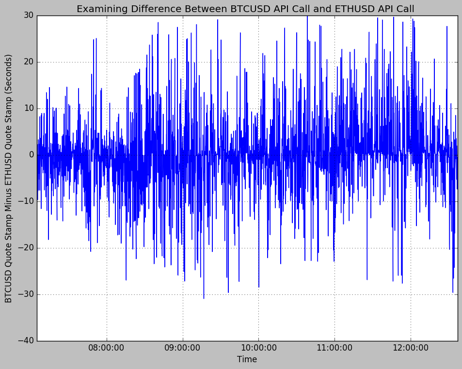

```python
plt.plot(list(data['polo_time_0'].values),data['BTCUSD_ETHUSD_Seconds'])
plt.title('Examining Difference Between BTCUSD API Call and ETHUSD API Call ')
plt.xlabel('Time')
plt.ylabel('BTCUSD Quote Stamp Minus ETHUSD Quote Stamp (Seconds)')
plt.grid()
plt.show()
```

The chart above shows the pricing of two markets coming from the same API (GDAX). So it is safe to assume that the API is providing the last trade for each currency pair, and we can ffill the data. The order book has probably changed during this time, but there are not likely any new trades in the currency pair that is lagging in terms of it's timestamp relative tot he currency pair with the newer timestamp.

For our strategy analysis initially, we will try to filter for when trades coming from the GDAX API are within a certain range of seconds from each other.

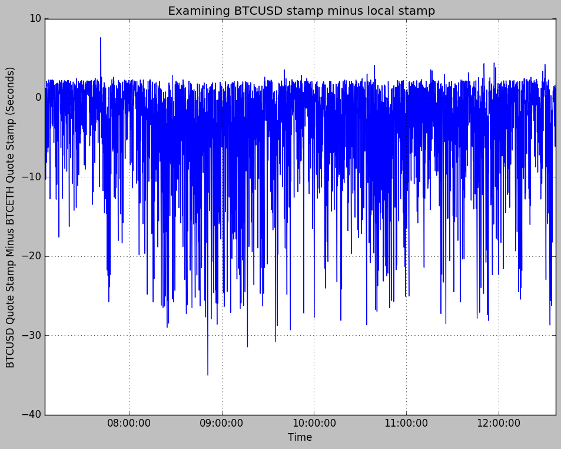

```python
plt.plot(list(data['polo_time_0'].values),data['BTCUSD_BTCETH_Seconds'])
plt.title(' Examining BTCUSD stamp minus local stamp')
plt.xlabel('Time')
plt.ylabel('BTCUSD Quote Stamp Minus BTCETH Quote Stamp (Seconds)')
plt.grid()
plt.show()
```

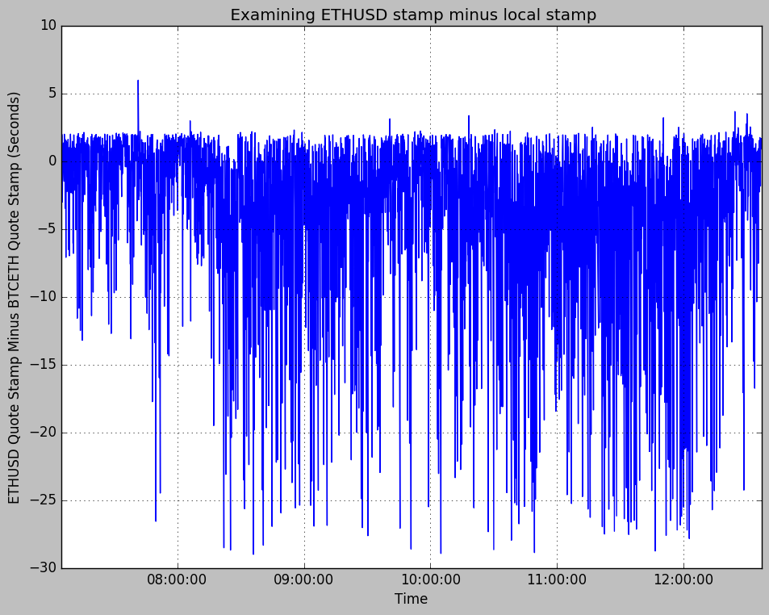

```python
plt.plot(list(data['polo_time_0'].values),data['ETHUSD_BTCETH_Seconds'])
plt.title(' Examining ETHUSD stamp minus local stamp')
plt.xlabel('Time')
plt.ylabel('ETHUSD Quote Stamp Minus BTCETH Quote Stamp (Seconds)')
plt.grid()
plt.show()
```

#### Conclusion

It will be easy enough to ffill the data from the two currencies streaming from the GDAX API, but the timestamp of trades coming from the Poloniex API is captured locally, which is a challenge. As noted before, it is probably neccesary to monitor both brokerages for market movements that may have occurred in real time, but were not reported by the most recent API call.

### Using most recent trade data at all times, determine if and when Triangle Arbitrage opportunities existed in this data set.

```python
data.head()
```

|  | polo_time_0 | polo_time_1 | BTCETH_PRICE | gdax_time_ETHUSD | ETHUSD_PRICE | gdax_time_BTCUSD | BTCUSD_PRICE | BTCUSD_ETHUSD_Delta | BTCUSD_BTCETH_Delta | ETHUSD_BTCETH_Delta | BTCUSD_ETHUSD_Seconds | BTCUSD_BTCETH_Seconds | ETHUSD_BTCETH_Seconds |
| --- | --- | --- | --- | --- | --- | --- | --- | --- | --- | --- | --- | --- | --- |
| 0 | 2017-07-11 02:04:43.239583-05:00 | 2017-07-11 02:04:43.643355-05:00 | 0.078497 | 2017-07-11 02:04:45.138000-05:00 | 182.83 | 2017-07-11 02:04:29.281000-05:00 | 2302.56 | -1 days +23:59:44.143000 | -1 days +23:59:45.637645 | 00:00:01.494645 | -15.857 | -14.362355 | 1.494645 |
| 1 | 2017-07-11 02:04:49.221453-05:00 | 2017-07-11 02:04:49.326083-05:00 | 0.078631 | 2017-07-11 02:04:49.375000-05:00 | 182.80 | 2017-07-11 02:04:46.809000-05:00 | 2302.56 | -1 days +23:59:57.434000 | -1 days +23:59:57.482917 | 00:00:00.048917 | -2.566 | -2.517083 | 0.048917 |
| 2 | 2017-07-11 02:04:54.605551-05:00 | 2017-07-11 02:04:54.720606-05:00 | 0.078497 | 2017-07-11 02:04:55.862000-05:00 | 181.60 | 2017-07-11 02:04:46.809000-05:00 | 2302.56 | -1 days +23:59:50.947000 | -1 days +23:59:52.088394 | 00:00:01.141394 | -9.053 | -7.911606 | 1.141394 |
| 3 | 2017-07-11 02:05:00.122692-05:00 | 2017-07-11 02:05:00.287866-05:00 | 0.078497 | 2017-07-11 02:04:58.567000-05:00 | 181.05 | 2017-07-11 02:04:59.356000-05:00 | 2304.26 | 00:00:00.789000 | -1 days +23:59:59.068134 | -1 days +23:59:58.279134 | 0.789 | -0.931866 | -1.720866 |
| 4 | 2017-07-11 02:05:05.774416-05:00 | 2017-07-11 02:05:05.902462-05:00 | 0.078396 | 2017-07-11 02:05:07.877000-05:00 | 181.29 | 2017-07-11 02:05:06.276000-05:00 | 2302.96 | -1 days +23:59:58.399000 | 00:00:00.373538 | 00:00:01.974538 | -1.601 | 0.373538 | 1.974538 |

# Strategy #1 - Buy BTCUSD from GDAX, Sell BTCETH from Poloniex, Sell ETHUSD from GDAX

```python
dollar_investment = 1000
### BUY BTCUSD from GDAX ######
data['BTCUSD_Value'] = dollar_investment / data['BTCUSD_PRICE'] # Provides Ownership of BTC
#data['BTCUSD_Value'] = data['BTCUSD_PRICE'] * data['BTCUSD_Units_Owned']
#################################

### Sell BTCETH from Poloniex #####
#data['EURGBP_Value'] = data['EURUSD_Value']*data['EURGBP_Bid'] # MARKET TAKER ## #REFERENCE CODE
#data['BTCETH_Units_Sold'] = data['BTCUSD_Units_Owned'] / data['BTCETH_PRICE']
#data['BTCETH_VALUE'] = data['BTCETH_PRICE'] * data['BTCETH_Units_Sold']
data['BTCETH_Value'] = data['BTCUSD_Value'] / data['BTCETH_PRICE']
###############################################################

### Sell ETHUSD from GDAX
# data['GBPUSD_Value'] = data['EURGBP_Value']*data['GBPUSD_Bid'] ### REFERENCE CODE
#data['ETHUSD_Units_Sold'] = dollar_investment / data['ETHUSD_PRICE']
data['ETHUSD_Value'] = data['BTCETH_Value']*data['ETHUSD_PRICE']

### Calculate Arb Entry PRofit
data['pre_profit'] = data['ETHUSD_Value'] - dollar_investment ## Reference code

data.head(3)
```

|  | polo_time_0 | polo_time_1 | BTCETH_PRICE | gdax_time_ETHUSD | ETHUSD_PRICE | gdax_time_BTCUSD | BTCUSD_PRICE | BTCUSD_ETHUSD_Delta | BTCUSD_BTCETH_Delta | ETHUSD_BTCETH_Delta | BTCUSD_ETHUSD_Seconds | BTCUSD_BTCETH_Seconds | ETHUSD_BTCETH_Seconds | BTCUSD_Value | BTCETH_Value | ETHUSD_Value | pre_profit |
| --- | --- | --- | --- | --- | --- | --- | --- | --- | --- | --- | --- | --- | --- | --- | --- | --- | --- |
| 0 | 2017-07-11 02:04:43.239583-05:00 | 2017-07-11 02:04:43.643355-05:00 | 0.078497 | 2017-07-11 02:04:45.138000-05:00 | 182.83 | 2017-07-11 02:04:29.281000-05:00 | 2302.56 | -1 days +23:59:44.143000 | -1 days +23:59:45.637645 | 00:00:01.494645 | -15.857 | -14.362355 | 1.494645 | 0.434299 | 5.532706 | 1011.544630 | 11.544630 |
| 1 | 2017-07-11 02:04:49.221453-05:00 | 2017-07-11 02:04:49.326083-05:00 | 0.078631 | 2017-07-11 02:04:49.375000-05:00 | 182.80 | 2017-07-11 02:04:46.809000-05:00 | 2302.56 | -1 days +23:59:57.434000 | -1 days +23:59:57.482917 | 00:00:00.048917 | -2.566 | -2.517083 | 0.048917 | 0.434299 | 5.523282 | 1009.655987 | 9.655987 |
| 2 | 2017-07-11 02:04:54.605551-05:00 | 2017-07-11 02:04:54.720606-05:00 | 0.078497 | 2017-07-11 02:04:55.862000-05:00 | 181.60 | 2017-07-11 02:04:46.809000-05:00 | 2302.56 | -1 days +23:59:50.947000 | -1 days +23:59:52.088394 | 00:00:01.141394 | -9.053 | -7.911606 | 1.141394 | 0.434299 | 5.532706 | 1004.739401 | 4.739401 |

```python
print ('Statistical Summary of Pre Commission Profit of Triangle Arbitrage')
print (data['pre_profit'].describe())
```

```
Statistical Summary of Pre Commission Profit of Triangle Arbitrage
count    3499.000000
mean        1.702307
std         4.354191
min       -11.132610
25%        -1.086849
50%         1.256623
75%         3.627065
max        35.853199
Name: pre_profit, dtype: float64
```

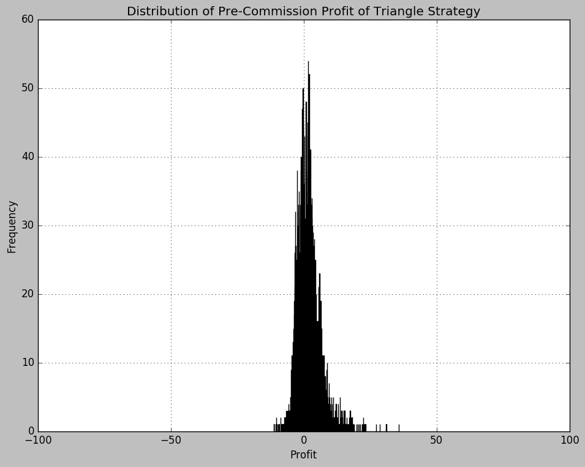

```python
plt.hist(data['pre_profit'],bins=500)
plt.title('Distribution of Pre-Commission Profit of Triangle Strategy')
plt.xlabel('Profit')
plt.ylabel('Frequency')
plt.xlim(-100,100)
plt.grid()
plt.show()
```

```python
arb = data[data['pre_profit']>0]
print ('Total Arbitrage Opportunities (Pre-Commission):',len(arb))
print ('Percentage of Ticks With Arbitrage Opportunities:',len(arb)/len(data))
```

```
Total Arbitrage Opportunities (Pre-Commission): 2179
Percentage of Ticks With Arbitrage Opportunities: 0.6227493569591311
```

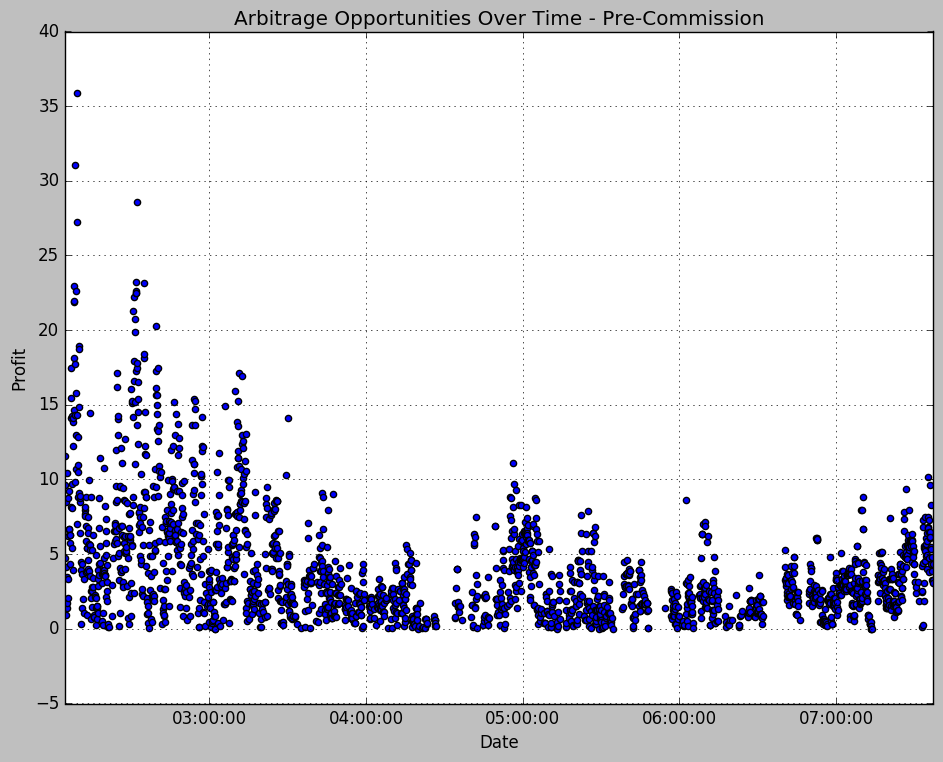

```python
plt.scatter(list(arb['polo_time_0']),arb['pre_profit'])
plt.title('Arbitrage Opportunities Over Time - Pre-Commission')
plt.xlabel('Date')
plt.ylabel('Profit')
plt.grid()
plt.xlim(np.min(arb['polo_time_0']),np.max(arb['polo_time_0']))
plt.show()
```

### Model In Commissions on Trades

Not yet able to locate Commmission Fees on GDAX..Will Make Assumption in model

Poloniex fee schedule - https://poloniex.com/fees/

0.15% commission on Poloniex Trades seems logical in future

##### For simplicity, model will initially utilize a total of $10 for all three trades

```python
data['profit'] = data['pre_profit'] - 10
data.head(3)
```

|  | polo_time_0 | polo_time_1 | BTCETH_PRICE | gdax_time_ETHUSD | ETHUSD_PRICE | gdax_time_BTCUSD | BTCUSD_PRICE | BTCUSD_ETHUSD_Delta | BTCUSD_BTCETH_Delta | ETHUSD_BTCETH_Delta | BTCUSD_ETHUSD_Seconds | BTCUSD_BTCETH_Seconds | ETHUSD_BTCETH_Seconds | BTCUSD_Value | BTCETH_Value | ETHUSD_Value | pre_profit | profit |
| --- | --- | --- | --- | --- | --- | --- | --- | --- | --- | --- | --- | --- | --- | --- | --- | --- | --- | --- |
| 0 | 2017-07-11 02:04:43.239583-05:00 | 2017-07-11 02:04:43.643355-05:00 | 0.078497 | 2017-07-11 02:04:45.138000-05:00 | 182.83 | 2017-07-11 02:04:29.281000-05:00 | 2302.56 | -1 days +23:59:44.143000 | -1 days +23:59:45.637645 | 00:00:01.494645 | -15.857 | -14.362355 | 1.494645 | 0.434299 | 5.532706 | 1011.544630 | 11.544630 | 1.544630 |
| 1 | 2017-07-11 02:04:49.221453-05:00 | 2017-07-11 02:04:49.326083-05:00 | 0.078631 | 2017-07-11 02:04:49.375000-05:00 | 182.80 | 2017-07-11 02:04:46.809000-05:00 | 2302.56 | -1 days +23:59:57.434000 | -1 days +23:59:57.482917 | 00:00:00.048917 | -2.566 | -2.517083 | 0.048917 | 0.434299 | 5.523282 | 1009.655987 | 9.655987 | -0.344013 |
| 2 | 2017-07-11 02:04:54.605551-05:00 | 2017-07-11 02:04:54.720606-05:00 | 0.078497 | 2017-07-11 02:04:55.862000-05:00 | 181.60 | 2017-07-11 02:04:46.809000-05:00 | 2302.56 | -1 days +23:59:50.947000 | -1 days +23:59:52.088394 | 00:00:01.141394 | -9.053 | -7.911606 | 1.141394 | 0.434299 | 5.532706 | 1004.739401 | 4.739401 | -5.260599 |

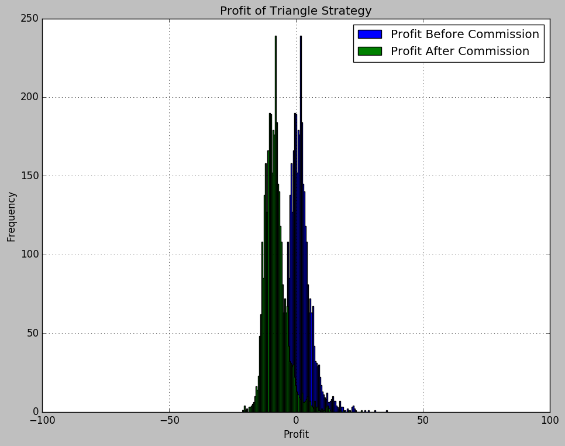

```python
plt.hist(data['pre_profit'],bins=100,label='Profit Before Commission')
plt.hist(data['profit'],bins=100,label='Profit After Commission')
plt.title('Profit of Triangle Strategy')
plt.xlabel('Profit')
plt.ylabel('Frequency')
plt.legend()
plt.xlim(-100,100)
plt.grid()
plt.show()
```

```python
real_arb = data[data['profit']>0]
print ('Total Arbitrage Opportunities (Post-Commission):',len(real_arb))
print ('Percentage of Ticks With Arbitrage Opportunities:',len(real_arb)/len(data))
```

```
Total Arbitrage Opportunities (Post-Commission): 146
Percentage of Ticks With Arbitrage Opportunities: 0.041726207487853675
```

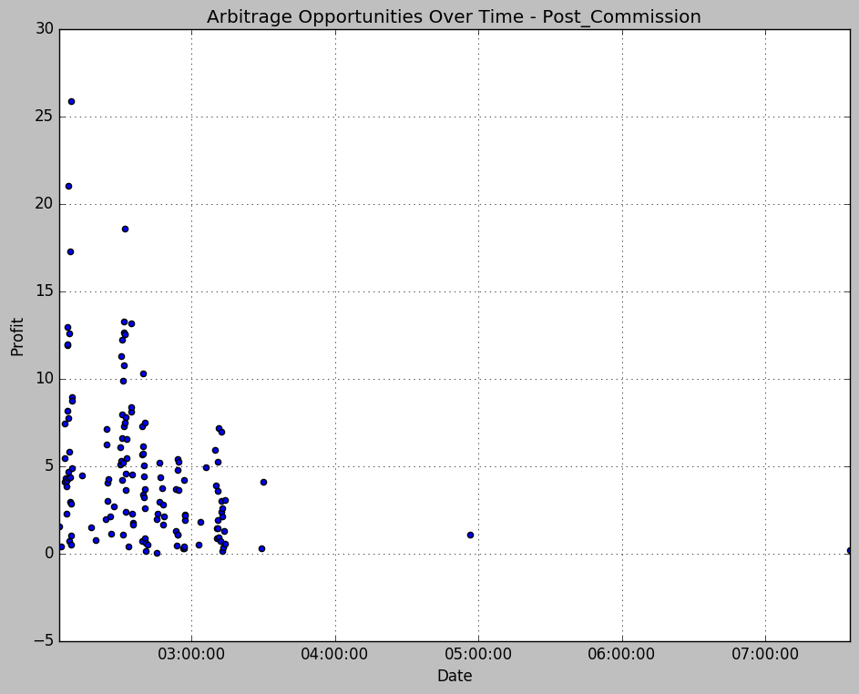

```python
plt.scatter(list(real_arb['polo_time_0']),real_arb['profit'])
plt.title('Arbitrage Opportunities Over Time - Post_Commission')
plt.xlabel('Date')
plt.ylabel('Profit')
plt.xlim(np.min(real_arb['polo_time_0']),np.max(real_arb['polo_time_0']))
plt.grid()
plt.show()
```

#### Filter down to only the $25+ Opportunity, and test different exit scenarios

```python
real_arb.columns
```

```
Index(['polo_time_0', 'polo_time_1', 'BTCETH_PRICE', 'gdax_time_ETHUSD',
       'ETHUSD_PRICE', 'gdax_time_BTCUSD', 'BTCUSD_PRICE',
       'BTCUSD_ETHUSD_Delta', 'BTCUSD_BTCETH_Delta', 'ETHUSD_BTCETH_Delta',
       'BTCUSD_ETHUSD_Seconds', 'BTCUSD_BTCETH_Seconds',
       'ETHUSD_BTCETH_Seconds', 'BTCUSD_Value', 'BTCETH_Value', 'ETHUSD_Value',
       'pre_profit', 'profit'],
      dtype='object')
```

```python
trade = real_arb[real_arb['profit']>25]
print ('Total Arb Entry Oppotunities Above $25:',len(trade))
print ('First Arb Entry Opp:',np.min(trade['polo_time_0']))
print ('Last Arb Entry Opp:',np.max(trade['polo_time_0']))
trade.head()
```

```
Total Arb Entry Oppotunities Above $25: 1
First Arb Entry Opp: 2017-07-11 02:09:29.042283-05:00
Last Arb Entry Opp: 2017-07-11 02:09:29.042283-05:00
```

|  | polo_time_0 | polo_time_1 | BTCETH_PRICE | gdax_time_ETHUSD | ETHUSD_PRICE | gdax_time_BTCUSD | BTCUSD_PRICE | BTCUSD_ETHUSD_Delta | BTCUSD_BTCETH_Delta | ETHUSD_BTCETH_Delta | BTCUSD_ETHUSD_Seconds | BTCUSD_BTCETH_Seconds | ETHUSD_BTCETH_Seconds | BTCUSD_Value | BTCETH_Value | ETHUSD_Value | pre_profit | profit |
| --- | --- | --- | --- | --- | --- | --- | --- | --- | --- | --- | --- | --- | --- | --- | --- | --- | --- | --- |
| 51 | 2017-07-11 02:09:29.042283-05:00 | 2017-07-11 02:09:29.171722-05:00 | 0.077 | 2017-07-11 02:09:26.825000-05:00 | 184.65 | 2017-07-11 02:09:28.070000-05:00 | 2315.05 | 00:00:01.245000 | -1 days +23:59:58.898278 | -1 days +23:59:57.653278 | 1.245 | -1.101722 | -2.346722 | 0.431956 | 5.60982 | 1035.853199 | 35.853199 | 25.853199 |

### When would have been the optimal time to exit this trade, and examine the maximum exposure risk over time.

##### Get prices at all times in future starting at $25 Arb Entry Point

```python
print ('Total Ticks in data',len(data))
data.columns
```

```
Total Ticks in data 3499
```

[output not shown]

##### Entry point is 51 on the index of all data points

```python
print (data.iloc[51])
```

```
polo_time_0              2017-07-11 02:09:29.042283-05:00
polo_time_1              2017-07-11 02:09:29.171722-05:00
BTCETH_PRICE                                        0.077
gdax_time_ETHUSD         2017-07-11 02:09:26.825000-05:00
ETHUSD_PRICE                                       184.65
gdax_time_BTCUSD         2017-07-11 02:09:28.070000-05:00
BTCUSD_PRICE                                      2315.05
BTCUSD_ETHUSD_Delta                0 days 00:00:01.245000
BTCUSD_BTCETH_Delta              -1 days +23:59:58.898278
ETHUSD_BTCETH_Delta              -1 days +23:59:57.653278
BTCUSD_ETHUSD_Seconds                               1.245
BTCUSD_BTCETH_Seconds                            -1.10172
ETHUSD_BTCETH_Seconds                            -2.34672
BTCUSD_Value                                     0.431956
BTCETH_Value                                      5.60982
ETHUSD_Value                                      1035.85
pre_profit                                        35.8532
profit                                            25.8532
Name: 51, dtype: object
```

```python
start = data[data.index >= 51]
print (len(start))
start.head(2)
```

```
3448
```

|  | polo_time_0 | polo_time_1 | BTCETH_PRICE | gdax_time_ETHUSD | ETHUSD_PRICE | gdax_time_BTCUSD | BTCUSD_PRICE | BTCUSD_ETHUSD_Delta | BTCUSD_BTCETH_Delta | ETHUSD_BTCETH_Delta | BTCUSD_ETHUSD_Seconds | BTCUSD_BTCETH_Seconds | ETHUSD_BTCETH_Seconds | BTCUSD_Value | BTCETH_Value | ETHUSD_Value | pre_profit | profit |
| --- | --- | --- | --- | --- | --- | --- | --- | --- | --- | --- | --- | --- | --- | --- | --- | --- | --- | --- |
| 51 | 2017-07-11 02:09:29.042283-05:00 | 2017-07-11 02:09:29.171722-05:00 | 0.077000 | 2017-07-11 02:09:26.825000-05:00 | 184.65 | 2017-07-11 02:09:28.070000-05:00 | 2315.05 | 00:00:01.245000 | -1 days +23:59:58.898278 | -1 days +23:59:57.653278 | 1.245 | -1.101722 | -2.346722 | 0.431956 | 5.609820 | 1035.853199 | 35.853199 | 25.853199 |
| 52 | 2017-07-11 02:09:34.706706-05:00 | 2017-07-11 02:09:34.845003-05:00 | 0.077566 | 2017-07-11 02:09:35.787000-05:00 | 182.36 | 2017-07-11 02:09:37.109000-05:00 | 2321.25 | 00:00:01.322000 | 00:00:02.263997 | 00:00:00.941997 | 1.322 | 2.263997 | 0.941997 | 0.430802 | 5.553997 | 1012.826983 | 12.826983 | 2.826983 |

##### Convert price movements to percent changes and visualize all pairs over time

```python
#PriceChange = cvs.diff().cumsum()
#PercentageChange = PriceChange / cvs.iloc[0]
BTCETH_Change = start['BTCETH_PRICE'].diff().cumsum()
start['BTCETH_Percent_Change'] = BTCETH_Change / start['BTCETH_PRICE'].iloc[0]

ETHUSD_Change = start['ETHUSD_PRICE'].diff().cumsum()
start['ETHUSD_Percent_Change'] = ETHUSD_Change / start['ETHUSD_PRICE'].iloc[0]

BTCUSD_Change = start['BTCUSD_PRICE'].diff().cumsum()
start['BTCUSD_Percent_Change'] = BTCUSD_Change / start['BTCUSD_PRICE'].iloc[0]

start.head(2)
```

|  | polo_time_0 | polo_time_1 | BTCETH_PRICE | gdax_time_ETHUSD | ETHUSD_PRICE | gdax_time_BTCUSD | BTCUSD_PRICE | BTCUSD_ETHUSD_Delta | BTCUSD_BTCETH_Delta | ETHUSD_BTCETH_Delta | ... | BTCUSD_BTCETH_Seconds | ETHUSD_BTCETH_Seconds | BTCUSD_Value | BTCETH_Value | ETHUSD_Value | pre_profit | profit | BTCETH_Percent_Change | ETHUSD_Percent_Change | BTCUSD_Percent_Change |
| --- | --- | --- | --- | --- | --- | --- | --- | --- | --- | --- | --- | --- | --- | --- | --- | --- | --- | --- | --- | --- | --- |
| 51 | 2017-07-11 02:09:29.042283-05:00 | 2017-07-11 02:09:29.171722-05:00 | 0.077000 | 2017-07-11 02:09:26.825000-05:00 | 184.65 | 2017-07-11 02:09:28.070000-05:00 | 2315.05 | 00:00:01.245000 | -1 days +23:59:58.898278 | -1 days +23:59:57.653278 | ... | -1.101722 | -2.346722 | 0.431956 | 5.609820 | 1035.853199 | 35.853199 | 25.853199 | NaN | NaN | NaN |
| 52 | 2017-07-11 02:09:34.706706-05:00 | 2017-07-11 02:09:34.845003-05:00 | 0.077566 | 2017-07-11 02:09:35.787000-05:00 | 182.36 | 2017-07-11 02:09:37.109000-05:00 | 2321.25 | 00:00:01.322000 | 00:00:02.263997 | 00:00:00.941997 | ... | 2.263997 | 0.941997 | 0.430802 | 5.553997 | 1012.826983 | 12.826983 | 2.826983 | 0.007353 | -0.012402 | 0.002678 |

2 rows × 21 columns

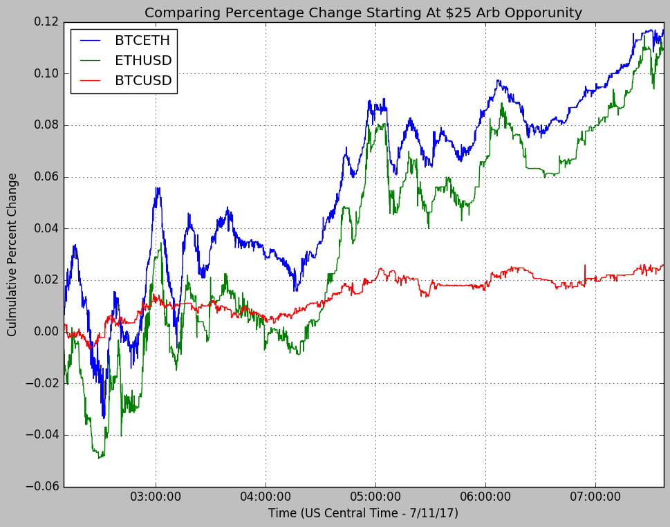

```python
plt.plot(list(start['polo_time_0']),start['BTCETH_Percent_Change'],label='BTCETH')
plt.plot(list(start['polo_time_0']),start['ETHUSD_Percent_Change'],label='ETHUSD')
plt.plot(list(start['polo_time_0']),start['BTCUSD_Percent_Change'],label='BTCUSD')
plt.title('Comparing Percentage Change Starting At $25 Arb Opporunity')
plt.ylabel('Culmulative Percent Change')
plt.xlabel('Time (US Central Time - 7/11/17)')
plt.legend(loc='upper left')
plt.grid()
plt.show()
```

##### The strategy is long the red line, and short green and blue, so this is not looking so good. Below, calculate profit in dollar denominated terms

##### Note- hit time limit working on this analysis. Quick calculations to understand profitability of trade is as follows:

```python
# 1% gain in BTCUSD in Dollar Terms =
print ('Profit of 1% Gain in BTCUSD',2315*1.01-2315)
print ('Loss of 1% Gain in BTCETH',(0.077*1.01-0.077)*2315*-1)
print ('Loss of 1% Gain in ETHUSD',(184.65*1.01-184.65)*-1)
```

```
Profit of 1% Gain in BTCUSD 23.15000000000009
Loss of 1% Gain in BTCETH -1.7825500000000156
Loss of 1% Gain in ETHUSD -1.8464999999999918
```

```python
start.tail(1)
```

|  | polo_time_0 | polo_time_1 | BTCETH_PRICE | gdax_time_ETHUSD | ETHUSD_PRICE | gdax_time_BTCUSD | BTCUSD_PRICE | BTCUSD_ETHUSD_Delta | BTCUSD_BTCETH_Delta | ETHUSD_BTCETH_Delta | ... | BTCUSD_BTCETH_Seconds | ETHUSD_BTCETH_Seconds | BTCUSD_Value | BTCETH_Value | ETHUSD_Value | pre_profit | profit | BTCETH_Percent_Change | ETHUSD_Percent_Change | BTCUSD_Percent_Change |
| --- | --- | --- | --- | --- | --- | --- | --- | --- | --- | --- | --- | --- | --- | --- | --- | --- | --- | --- | --- | --- | --- |
| 3498 | 2017-07-11 07:37:04.250453-05:00 | 2017-07-11 07:37:04.393849-05:00 | 0.086 | 2017-07-11 07:37:05.292000-05:00 | 204.83 | 2017-07-11 07:37:03.887000-05:00 | 2374.46 | -1 days +23:59:58.595000 | -1 days +23:59:59.493151 | 00:00:00.898151 | ... | -0.506849 | 0.898151 | 0.421148 | 4.897074 | 1003.067723 | 3.067723 | -6.932277 | 0.116883 | 0.109288 | 0.025663 |

1 rows × 21 columns

```python
print ('Total Gain on Entry Arbitrage:',25)
print ('Total Gain on BTCUSD Trade:',23.15*2.5663)
print ('Total Loss on BTCETH Trade:',-1.78255*11.6883)
print ('Total Loss on ETHUSD Trade:',-1.84649*10.9288)
```

```
Total Gain on Entry Arbitrage: 25
Total Gain on BTCUSD Trade: 59.409845
Total Loss on BTCETH Trade: -20.834979165
Total Loss on ETHUSD Trade: -20.179919912000003
```

```python
print ('Total Round Trip Trade Profit:',25+59.409-20.83-20.17)
```

```
Total Round Trip Trade Profit: 43.40899999999999
```